# TAE - Unit 6 - Lecture 1

GT

18 mai 2016

## Reccomendations Worth a Million

In this lecture, we’ll be discussing the story of Netflix and how their recommendation system is worth a million dollars.

Through this example, we’ll introduce the method of *clustering*.

Netflix is an online DVD rental and streaming video service. Customers can receive movie rentals by mail, and they can also watch selected movies and TV shows online.

Netflix has more than 40 million subscribers worldwide and has an annual revenue of $3.6 billion.

A key aspect of the company is being able to offer customers accurate movie recommendations based on a customer’s own preferences and viewing history.

From 2006 through 2009, Netflix ran a contest asking the public to submit algorithms to predict user ratings for movies. This algorithm would be useful for Netflix when making recommendations to users.

Netflix provided a training data set of about 100 million user ratings and a test data set of about three million user ratings.

They offered a grand prize of one million dollars to the team who could beat Netflix’s current algorithm, called Cinematch, by more than 10% measured in terms of root mean squared error.

Netflix believed that their recommendation system was so valuable that it was worth a million dollars to improve.

The contest had a few rules.

One was that if the grand prize was not yet reached, progress prizes of $50,000 per year would be awarded for the best result so far, as long as it was at least a 1% improvement over the previous year.

Another rule was that teams must submit their code and a description of the algorithm to be awarded any prizes.

And lastly, if a team met the 10% improvement goal, a last call would be issued, and 30 days would remain for all teams to submit their best algorithm.

So what happened?

The contest went live on October 2, 2006.

- By October 8, only six days later, a team submitted an algorithm that beat Cinematch.
- A week later, on October 15, there were three teams already submitting algorithms beating Cinematch.
- One of these solutions beat Cinematch by more than 1%, already qualifying for a progress prize.

The contest was hugely popular all over the world. By June 2007, over 20,000 teams had registered from over 150 countries. The 2007 progress prize went to a team called BellKor, with an 8.43% improvement over Cinematch. The following year, several teams from across the world joined forces to improve the accuracy even further.

In 2008, the progress prize again went to team BellKor. But this time, the team included members from the team BigChaos in addition to the original members of BellKor.

This was the last progress prize because another 1% improvement would reach the grand prize goal of 10%. On June 26, 2009, the team BellKor’s Pragmatic Chaos, composed of members from three different original teams, submitted a 10.05% improvement over Cinematch, signaling the last call for the contest.

Other teams had 30 days to submit algorithms before the contest closed. These 30 days were filled with intense competition and even more progress.

### Reccomendation Systems

Now, we’ll discuss how recommendation systems work.

Let’s start by thinking about the data. When predicting user ratings, what data could be useful?

There are two main types of data that we could use.

The first is that for every movie in Netflix’s database, we have a ranking from all users who have ranked that movie.

The second is that we know facts about the movie itself, the actors in the movie, the director, the genre classifications of the movie, the year it was released, et cetera.

As an example, suppose we have the following user ratings for four users and four movies. As we discussed in the previous video, Our users are Amy, Bob, Carl, and Dan. And our movies are Men in Black, Apollo 13, Top Gun, and Terminator. The ratings are on a one to five scale, where one is the lowest rating and five is the highest rating. The blank entries mean that the user has not rated the movie.

```
------------------------------------------------------
     | Men in Black | Apollo 13 | Top Gun | Terminator
------------------------------------------------------
Amy  |       5      |      4    |     5   |    4
------------------------------------------------------
Bob  |       3      |           |     2   |    5
------------------------------------------------------
Carl |              |      5    |     4   |    4
------------------------------------------------------
Dan  |       4      |      2    |         |
------------------------------------------------------
```

We could suggest to Carl that he watch Men in Black, since Amy rated it highly. She gave it a rating of five, and Amy and Carl seem to have similar ratings for the other movies.

This technique of using other user’s ratings to make predictions is called **collaborative filtering**.

Note that we’re not using any information about the movie itself here, just the similarity between users.

We saw in the table that Amy liked Men in Black. She gave it a rating of five. We know that this movie was directed by Barry Sonnenfeld, is classified in the genres of action, adventure, sci-fi, and comedy, and it stars actor Will Smith. Based on this information, we could make recommendations to Amy.

We could recommend to Amy another movie by the same director, Barry Sonnenfeld’s movie, Get Shorty. We can instead recommend the movie Jurassic Park, which is also classified in the genres of action, adventure, and sci-fi. Or we could recommend to Amy another movie starring Will Smith, Hitch.

Note that we’re not using the ratings of other users at all here, just information about the movie.

This technique is called **content filtering**.

There are strengths and weaknesses to both types of recommendation systems.

*Collaborative filtering*

- can accurately suggest complex items without understanding the nature of the items. We were just comparing user ratings.
- this requires a lot of data about the user to make accurate recommendations.
- when there are millions of items, it needs a lot of computing power to compute the user similarities.

*Content filtering*

- requires very little data to get started.
- But the major weakness of content filtering is that it can be limited in scope. You’re only recommending similar things to what the user has already liked. So the recommendations are often not surprising or particularly insightful.

Netflix actually uses what’s called a **hybrid recommendation system**.

They use both collaborative and content filtering.

As an example, consider a collaborative filtering approach, where we determine that Amy and Carl have similar preferences. We could then do content filtering as well, where we could find that the movie Terminator, which they both liked, is classified in almost the same set of genres as Starship Troopers.

So then we could recommend Starship Troopers to both Amy and Carl, even though neither of them have seen it before.

If we were only doing collaborative filtering, one of them would have had to have seen it before. And if we were only doing content filtering, we would only be recommending to one user at a time.

So by combining the two methods, the algorithm can be much more efficient and accurate.

### Movie Data and Clustering

In this lecture, we’ll be using data from MovieLens to explain clustering and perform content filtering.

movielens.org is a movie recommendation website run by the GroupLens research lab at the University of Minnesota.

They collect user preferences about movies and do collaborative filtering to make recommendations to users, based on the similarities between users.

We’ll use their movie database to do content filtering using a technique called **clustering**.

Movies in the MovieLens data set are categorized as belonging to different genres. There are 18 different genres as well as an unknown category.

The genres include crime, musical, mystery,and children’s.

Each movie may belong to many different genres. So a movie could be classified as drama, adventure, and sci-fi.

The question we want to answer is, can we systematically find groups of movies with similar sets of genres?

To answer this question, we’ll use a method called *clustering*.

Clustering is different from the other analytics methods we’ve covered so far.

It’s called an **unsupervised** learning method.

This means that we’re just trying to segment the data into similar groups, instead of trying to predict an outcome.

```
^
|
|     *
|   ****
|  **** *          oooo
| *  *           ooo o
|             oooo
|
|
|    x
|     xxxx
|   x x x
|     x
+----------------------------->
```

In this graph, based on the locations of points, we’ve divided them into three clusters, a ’*‘cluster, a ’o’ cluster, and a ‘x’ cluster.

This is the goal of clustering, to put each data point into a group with similar values in the data. A clustering algorithm does not predict anything.

However, clustering can be used to improve predictive methods. You can cluster the data into similar groups and then build a predictive model for each group. This can often improve the accuracy of predictive methods. But as a warning, be careful not to over-fit your model to the training set.

This works best for large data sets.

There are many different algorithms for clustering.

They differ in what makes a cluster and how the clusters are found.

In this class, we’ll cover

- hierarchical clustering
- K-means clustering.

There are other clustering methods also, but hierarchical and K-means are two of the most popular methods. To cluster data points, we need to compute how similar the points are.

### Computing Distnces

So how does clustering work?

The first step in clustering is to define the distance between two data points.

The most popular way to compute the distance is what’s called Euclidean distance. This is the standard way to compute distance that you might have seen before.

Suppose we have two data points, $i$ and $j$. The distance between the two points, which we’ll call $d_{ij}$, is equal to

$$d_{ij}=\sqrt{(x_{i1}-x_{j1})^2+(x_{i2}-x_{j2})^2+...+(x_{ik}-x_{jk})^2}$$

where $k$ here is the number of attributes or independent variables.

Let’s see how this works by looking at an example.

In our movie lens dataset, we have binary vectors for each movie, classifying that movie into genres.

The movie ‘Toy Story’ is categorized as an animation, comedy, and children’s movie. So the data for Toy Story has (0,0,0,1,1,1,0,0,0,0,0,0,0,0,0,0,0,0,0).

The movie ‘Batman Forever’ is categorized as an action, adventure, comedy, and crime movie. So Batman Forever has (0,1,1,0,0,1,1,0,0,0,0,0,0,0,0,0,0,0,0).

So given these two data observations, let’s compute the distance between them.

$$d=\sqrt{(0-0)^2+(0-1)^2+(0-1)^2+(1-0)^2+...}=\sqrt{5}$$

In addition to Euclidean distance, there are many other popular distance metrics that could be used.

One is called *Manhattan distance*, where the distance is computed to be the sum of the absolute values instead of the sum of squares.

Another is called *Maximum Coordinate distance*, where we only consider the measurement for which the data points deviate the most.

Another important distance that we have to calculate for clustering is the *Distance Between Clusters*, when a cluster is a group of data points.

How do we compute the distance between groups of points?

One way of doing this is by using what’s called the *minimum distance*.

This defines the distance between clusters as the distance between the two data points in the clusters that are closest together.

For example, we would define the distance between the ’*‘and ’o’ clusters by computing the Euclidean distance between these two points.

```
^
|           distance
|     *     /|
|   ****   / |
|  **** * *  |      oooo
| *  *       o  ooo o
|             oooo
|
|
|    x
|     xxxx
|   x x x
|     x
+----------------------------->
```

The other points in the clusters could be really far away, but it doesn’t matter if we use minimum distance.

The only thing we care about is how close together the closest points are.

Alternatively, we could use *maximum distance*. This one computes the distance between the two clusters as the distance between the two points that are the farthest apart.

So for example, we would compute the distance between the ’*‘and ’o’ clusters by looking at these two points.

```
^
|           distance min
|     *     /|
|   ****   / |
|  **** * *  |      oooo
| *  *       o  ooo o  o
|   \          oooo   /
|    \_distance max__/
|
|    x
|     xxxx
|   x x x
|     x
+----------------------------->
```

Here, it doesn’t matter how close together the other points are. All we care about is how close together the furthest points are.

The most common distance metric between clusters is called *centroid distance*. And this is what we’ll use.

It defines the distance between clusters by computing the centroid of the clusters.

The *centroid* is just the data point that takes the average of all data points in each component. This takes all data points in each cluster into account and can be thought of as the middle data point.

In our example, the centroids between ’*‘and ’o’ are here, and we would compute the distance between the clusters by computing the Euclidean distance between those two points.

```
^     distance centr
|        /    \
|     * /      \
|   ***/*       \
|  **** * *      \oooo
| *  *       o  ooo o
|             oooo
|    x
|     xxxx
|   x x x
|     x
+----------------------------->
```

When we are computing distances, it’s highly influenced by the scale of the variables.

As an example, suppose you’re computing the distance between two data points, where one variable is the revenue of a company in thousands of dollars, and another is the age of the company in years.

The revenue variable would really dominate in the distance calculation. The differences between the data points for revenue would be in the thousands. Whereas the differences between the year variable would probably be less than 10.

To handle this, it’s customary to *normalize* the data first.

We can normalize by subtracting the mean of the data and dividing by the standard deviation.

In our movie data set, all of our genre variables are on the same scale. So we don’t have to worry about normalizing. But if we wanted to add a variable, like box office revenue, we would need to normalize so that this variable didn’t dominate all of the others.

### Hierarchical Clustering

In hierarchical clustering, the clusters are formed by each data point starting in its own cluster.

As a small example, suppose we have five data points. Each data point is labeled as belonging in its own cluster. So this data point is in the red cluster, this one’s in the blue cluster, this one’s in the purple cluster, this one’s in the green cluster, and this one’s in the yellow cluster.

Then hierarchical clustering combines the two nearest clusters into one cluster.

We’ll use Euclidean and Centroid distances to decide which two clusters are the closest.

In our example, the green and yellow clusters are closest together.

So we would combine these two clusters into one cluster. So now the green cluster has two points, and the yellow cluster is gone.

Now this process repeats. We again find the two nearest clusters, which this time are the green cluster and the purple cluster, and we combine them into one cluster.

Now the green cluster has three points, and the purple cluster is gone.

Now the two nearest clusters are the red and blue clusters. So we would combine these two clusters into one cluster, the red cluster. So now we have just two clusters, the red one and the green one.

So now the final step is to combine these two clusters into one cluster.

So at the end of hierarchical clustering, all of our data points are in a single cluster.

The hierarchical cluster process can be displayed through what’s called a *dendrogram*.

```
  4+            +---------------------+
   |            |                     |
   |            |                     |
  3+            |                     |
   |            |                     |
   |            |                     |
  2+            |                     |
   |            |                     |
   |            |                     |
  1+  +---------------+         +-----------+
   |  |               |         |           |
   |  3          +--------+     2           5
0.5+             |        |
                 1        4
```

The data points are listed along the bottom, and the lines show how the clusters were combined.

The height of the lines represents how far apart the clusters were when they were combined.

So points 1 and 4 were pretty close together when they were combined. But when we combined the two clusters at the end, they were significantly farther apart.

We can use a dendrogram to decide how many clusters we want for our final clustering model.

The easiest way to pick the number of clusters you want is to draw a horizontal line across the dendrogram. The number of vertical lines that line crosses is the number of clusters there will be.

The farthest this horizontal line can move up and down in the dendrogram without hitting one of the horizontal lines of the dendrogram, the better that choice of the number of clusters is.

But when picking the number of clusters, you should also consider how many clusters make sense for the particular application you’re working with.

After selecting the number of clusters you want, you should analyze your clusters to see if they’re meaningful. This can be done by looking at basic statistics in each cluster, like the mean, maximum, and minimum values in each cluster and each variable.

You can also check to see if the clusters have a feature in common that was not used in the clustering, like an outcome variable. This often indicates that your clusters might help improve a predictive model.

### Getting the Data

Let’s switch to R and load our data, we’ll be using a slightly different command this time because the data is not a CSV file. It’s a text file, where the entries are separated by a vertical bar.

```r
movies = read.table("movieLens.txt", header=FALSE, sep="|", quote = "\"")
# the last argument just made sure that our text is read in properly
str(movies)
```

```
## 'data.frame':    1682 obs. of  24 variables:
##  $ V1 : int  1 2 3 4 5 6 7 8 9 10 ...
##  $ V2 : Factor w/ 1664 levels "101 Dalmatians (1996)",..: 1525 617 554 593 343 1317 1545 108 390 1238 ...
##  $ V3 : Factor w/ 241 levels "","01-Aug-1997",..: 71 71 71 71 71 71 71 71 71 182 ...
##  $ V4 : logi  NA NA NA NA NA NA ...
##  $ V5 : Factor w/ 1661 levels "","http://us.imdb.com/M/title-exact?06%20(1994)",..: 1431 564 504 542 309 1661 1453 102 356 1183 ...
##  $ V6 : int  0 0 0 0 0 0 0 0 0 0 ...
##  $ V7 : int  0 1 0 1 0 0 0 0 0 0 ...
##  $ V8 : int  0 1 0 0 0 0 0 0 0 0 ...
##  $ V9 : int  1 0 0 0 0 0 0 0 0 0 ...
##  $ V10: int  1 0 0 0 0 0 0 1 0 0 ...
##  $ V11: int  1 0 0 1 0 0 0 1 0 0 ...
##  $ V12: int  0 0 0 0 1 0 0 0 0 0 ...
##  $ V13: int  0 0 0 0 0 0 0 0 0 0 ...
##  $ V14: int  0 0 0 1 1 1 1 1 1 1 ...
##  $ V15: int  0 0 0 0 0 0 0 0 0 0 ...
##  $ V16: int  0 0 0 0 0 0 0 0 0 0 ...
##  $ V17: int  0 0 0 0 0 0 0 0 0 0 ...
##  $ V18: int  0 0 0 0 0 0 0 0 0 0 ...
##  $ V19: int  0 0 0 0 0 0 0 0 0 0 ...
##  $ V20: int  0 0 0 0 0 0 0 0 0 0 ...
##  $ V21: int  0 0 0 0 0 0 1 0 0 0 ...
##  $ V22: int  0 1 1 0 1 0 0 0 0 0 ...
##  $ V23: int  0 0 0 0 0 0 0 0 0 1 ...
##  $ V24: int  0 0 0 0 0 0 0 0 0 0 ...
```

We have 1,682 observations of 24 different variables. Since our variables didn’t have names, header equaled false, R just labeled them with V1, V2, V3, etc. But from the Movie Lens documentation, we know what these variables are.

```r
colnames(movies) = c("ID", "Title", "ReleaseDate", "VideoReleaseDate", "IMDB", "Unknown", "Action", "Adventure", "Animation", "Childrens", "Comedy", "Crime", "Documentary", "Drama", "Fantasy", "FilmNoir", "Horror", "Musical", "Mystery", "Romance", "SciFi", "Thriller", "War", "Western")
str(movies)
```

```
## 'data.frame':    1682 obs. of  24 variables:
##  $ ID              : int  1 2 3 4 5 6 7 8 9 10 ...
##  $ Title           : Factor w/ 1664 levels "101 Dalmatians (1996)",..: 1525 617 554 593 343 1317 1545 108 390 1238 ...
##  $ ReleaseDate     : Factor w/ 241 levels "","01-Aug-1997",..: 71 71 71 71 71 71 71 71 71 182 ...
##  $ VideoReleaseDate: logi  NA NA NA NA NA NA ...
##  $ IMDB            : Factor w/ 1661 levels "","http://us.imdb.com/M/title-exact?06%20(1994)",..: 1431 564 504 542 309 1661 1453 102 356 1183 ...
##  $ Unknown         : int  0 0 0 0 0 0 0 0 0 0 ...
##  $ Action          : int  0 1 0 1 0 0 0 0 0 0 ...
##  $ Adventure       : int  0 1 0 0 0 0 0 0 0 0 ...
##  $ Animation       : int  1 0 0 0 0 0 0 0 0 0 ...
##  $ Childrens       : int  1 0 0 0 0 0 0 1 0 0 ...
##  $ Comedy          : int  1 0 0 1 0 0 0 1 0 0 ...
##  $ Crime           : int  0 0 0 0 1 0 0 0 0 0 ...
##  $ Documentary     : int  0 0 0 0 0 0 0 0 0 0 ...
##  $ Drama           : int  0 0 0 1 1 1 1 1 1 1 ...
##  $ Fantasy         : int  0 0 0 0 0 0 0 0 0 0 ...
##  $ FilmNoir        : int  0 0 0 0 0 0 0 0 0 0 ...
##  $ Horror          : int  0 0 0 0 0 0 0 0 0 0 ...
##  $ Musical         : int  0 0 0 0 0 0 0 0 0 0 ...
##  $ Mystery         : int  0 0 0 0 0 0 0 0 0 0 ...
##  $ Romance         : int  0 0 0 0 0 0 0 0 0 0 ...
##  $ SciFi           : int  0 0 0 0 0 0 1 0 0 0 ...
##  $ Thriller        : int  0 1 1 0 1 0 0 0 0 0 ...
##  $ War             : int  0 0 0 0 0 0 0 0 0 1 ...
##  $ Western         : int  0 0 0 0 0 0 0 0 0 0 ...
```

We can see that we have the same number of observations and the same number of variables, but each of them now has the name that we just gave.

We won’t be using the ID, release date, video release date, or IMDB variables, so let’s go ahead and remove them.

```r
movies$ID = NULL
movies$ReleaseDate = NULL
movies$VideoReleaseDate = NULL
movies$IMDB = NULL
```

And there are a few duplicate entries in our data set, so we’ll go ahead and remove them with the unique function.

```r
movies = unique(movies)
str(movies)
```

```
## 'data.frame':    1664 obs. of  20 variables:
##  $ Title      : Factor w/ 1664 levels "101 Dalmatians (1996)",..: 1525 617 554 593 343 1317 1545 108 390 1238 ...
##  $ Unknown    : int  0 0 0 0 0 0 0 0 0 0 ...
##  $ Action     : int  0 1 0 1 0 0 0 0 0 0 ...
##  $ Adventure  : int  0 1 0 0 0 0 0 0 0 0 ...
##  $ Animation  : int  1 0 0 0 0 0 0 0 0 0 ...
##  $ Childrens  : int  1 0 0 0 0 0 0 1 0 0 ...
##  $ Comedy     : int  1 0 0 1 0 0 0 1 0 0 ...
##  $ Crime      : int  0 0 0 0 1 0 0 0 0 0 ...
##  $ Documentary: int  0 0 0 0 0 0 0 0 0 0 ...
##  $ Drama      : int  0 0 0 1 1 1 1 1 1 1 ...
##  $ Fantasy    : int  0 0 0 0 0 0 0 0 0 0 ...
##  $ FilmNoir   : int  0 0 0 0 0 0 0 0 0 0 ...
##  $ Horror     : int  0 0 0 0 0 0 0 0 0 0 ...
##  $ Musical    : int  0 0 0 0 0 0 0 0 0 0 ...
##  $ Mystery    : int  0 0 0 0 0 0 0 0 0 0 ...
##  $ Romance    : int  0 0 0 0 0 0 0 0 0 0 ...
##  $ SciFi      : int  0 0 0 0 0 0 1 0 0 0 ...
##  $ Thriller   : int  0 1 1 0 1 0 0 0 0 0 ...
##  $ War        : int  0 0 0 0 0 0 0 0 0 1 ...
##  $ Western    : int  0 0 0 0 0 0 0 0 0 0 ...
```

Now, we have 1,664 observations, a few less than before, and 20 variables, the title of the movie, the unknown genre label, and then the 18 other genre labels.

### Hierarchical Clustering in R

Now we’ll use hierarchical clustering to cluster the movies in the Movie Lens data set by genre. After we make our clusters, we’ll see how they can be used to make recommendations.

There are two steps to hierarchical clustering.

First we have to compute the distances between all data points, and then we need to cluster the points.

To compute the distances we can use the dist function. We only want to cluster our movies on the genre variable, not on the title variable, so we’ll cluster on columns 2 through 20.

```r
distances = dist(movies[2:20], method="euclidean")
```

Now let’s cluster our movies using the hclust function for hierarchical clustering.

```r
clusterMovies = hclust(distances, method="ward.D")
```

The ward method cares about the distance between clusters using centroid distance, and also the variance in each of the clusters.

Now let’s plot the dendrogram of our clustering algorithm.

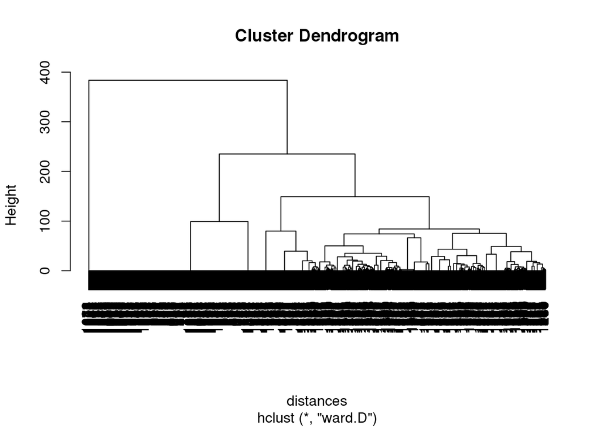

```r
plot(clusterMovies)
```

This dendrogram might look a little strange. We have all this black along the bottom. Remember that the dendrogram lists all of the data points along the bottom. But when there are over 1,000 data points it’s impossible to read.

So looking at this dendrogram, how many clusters would you pick?

It looks like maybe three or four clusters would be a good choice according to the dendrogram, but let’s keep our application in mind, too.

We probably want more than two, three, or even four clusters of movies to make recommendations to users. It looks like there’s a nice spot down here where there’s 10 clusters. This is probably better for our application.

You need to use your understanding of the problem to pick the number of clusters.

Now back in our R console we can label each of the data points according to what cluster it belongs to using the cutree function.

```r
clusterGroups = cutree(clusterMovies, k=10)
```

Now let’s figure out what the clusters are like. We’ll use the tapply function to compute the percentage of movies in each genre and cluster.

```r
tapply(movies$Action, clusterGroups, mean)
```

```
##         1         2         3         4         5         6         7
## 0.1784512 0.7839196 0.1238532 0.0000000 0.0000000 0.1015625 0.0000000
##         8         9        10
## 0.0000000 0.0000000 0.0000000
```

So what does this do? It divides our data points into the 10 clusters and then computes the average value of the action variable for each cluster.

Remember that the action variable is a binary variable with value 0 or 1. So by computing the average of this variable we’re computing the percentage of movies in that cluster that belong in that genre.

We can see here that in cluster 2, about 78% of the movies have the action genre label, whereas in cluster 4 none of the movies are labeled as action movies.

Let’s try this again, but this time let’s look at the romance genre.

```r
tapply(movies$Romance, clusterGroups, mean)
```

```
##          1          2          3          4          5          6
## 0.10437710 0.04522613 0.03669725 0.00000000 0.00000000 1.00000000
##          7          8          9         10
## 1.00000000 0.00000000 0.00000000 0.00000000
```

Here we can see that all of the movies in clusters six and seven are labeled as romance movies, whereas only 4% of the movies in cluster two are labeled as romance movies.

We can repeat this for each genre.

If you do you can create a large table to better analyze the clusters, which I saved to a csv file ClusterMeans.csv

```r
clusterMeans = read.csv("ClusterMeans.csv")
clusterMeans
```

```
##              X Cluster.1              Cluster.2              Cluster.3
## 1       Action      0.18                   0.78                   0.12
## 2    Adventure      0.19                   0.35                   0.04
## 3    Animation      0.13                   0.01                   0.00
## 4    Childrens      0.39                   0.01                   0.01
## 5       Comedy      0.36                   0.07                   0.06
## 6        Crime      0.03                   0.01                   0.41
## 7  Documentary      0.01                   0.00                   0.00
## 8        Drama      0.31                   0.11                   0.38
## 9      Fantasy      0.07                   0.00                   0.00
## 10   Film Noir      0.00                   0.00                   0.11
## 11      Horror      0.02                   0.08                   0.02
## 12     Musical      0.19                   0.00                   0.00
## 13     Mystery      0.00                   0.00                   0.28
## 14     Romance      0.10                   0.05                   0.04
```

[output cut: 45 more lines]

Lets take a look. Here we have in each column the cluster, and in each row the genre.

So we can see here in cluster 2, as we saw before, that cluster 2 has a high number of action movies.

- Cluster 1 has a little bit of everything, some animation, children’s, fantasy, musicals, war and westerns. So I’m calling this the miscellaneous cluster.
- Cluster 2 has a lot of the action, adventure, and sci-fi movies.
- Cluster 3 has the crime, mystery, thriller movies.
- Cluster 4 exclusively has drama movies.
- Cluster 5, exclusively has comedies.
- Cluster 6 has a lot of the romance movies.
- Cluster 7 has movies that are comedies and romance movies, so I’m calling these the romantic comedies.
- Cluster 8 has the documentaries.
- Cluster 9 has the movies that are comedies and dramas, so the dramatic comedies.
- Cluster 10 has the horror flicks.

Knowing common movie genres, these clusters seem to make a lot of sense.

So now let’s see how these clusters could be used in a recommendation system.

Remember that Amy liked the movie Men in Black. Let’s figure out what cluster Men in Black is in.

```r
subset(movies, Title=="Men in Black (1997)")
```

```
##                   Title Unknown Action Adventure Animation Childrens
## 257 Men in Black (1997)       0      1         1         0         0
##     Comedy Crime Documentary Drama Fantasy FilmNoir Horror Musical Mystery
## 257      1     0           0     0       0        0      0       0       0
##     Romance SciFi Thriller War Western
## 257       0     1        0   0       0
```

It looks like Men in Black is the 257th row in our data. So which cluster did the 257th movie go into?

```r
clusterGroups[257]
```

```
## 257
##   2
```

It looks like Men in Black went into cluster 2. That make sense since we just saw that cluster 2 is the action, adventure, sci-fi cluster.

So let’s create a new data set with just the movies from cluster two.

```r
cluster2 = subset(movies, clusterGroups == 2)
cluster2$Title[1:10]
```

```
##  [1] GoldenEye (1995)
##  [2] Bad Boys (1995)
##  [3] Apollo 13 (1995)
##  [4] Net, The (1995)
##  [5] Natural Born Killers (1994)
##  [6] Outbreak (1995)
##  [7] Stargate (1994)
##  [8] Fugitive, The (1993)
##  [9] Jurassic Park (1993)
## [10] Robert A. Heinlein's The Puppet Masters (1994)
## 1664 Levels: 101 Dalmatians (1996) 12 Angry Men (1957) ... Zeus and Roxanne (1997)
```

So it looks like good movies to recommend to Amy, according to our clustering algorithm, would be movies like Apollo 13 and Jurassic Park.

### The Analytics Edge of Recommendation Systems

Recommendation systems are used in many different areas other than movies.

Jeff Bezos, the CEO of Amazon, said that, “If I have 3 million customers on the web, I should have 3 million stores on the web.”

The internet allows for mass personalization, and recommendation systems are a key part of that. Recommendation systems build models about users’ preferences to personalize the user experience.

This helps users find items they might not have searched for, like a new favorite band, an old friend who uses the same social media network, or a book or song that they’re likely to enjoy.

Recommendation systems are a cornerstone of these top businesses. Social networking sites, like Facebook, music streaming sites, like Pandora, and retail companies, like Amazon, all provide recommendation systems for their users.

Both collaborative filtering and content filtering are used in practice.

Collaborative filtering is used by companies like Amazon, Facebook, and Google News.

Content filtering is used by companies like Pandora, Rotten Tomatoes, and See This Next.

And Netflix uses both collaborative filtering and content filtering.

So now let’s go back to the Netflix prize.

29 days after last call was announced, on July 25, 2009, the team The Ensemble submitted a 10.09% improvement, beating the 10.05% improvement that was submitted by Bellkor’s Pragmatic Chaos to signal last call.

But by the time Netflix stopped accepting submissions the next day, Bellkor’s Pragmatic Chaos had also submitted a 10.09% improvement, and The Ensemble had submitted a 10.10% improvement.

To really test the algorithms, Netflix tested them on a private test set that the teams had never seen before.

This is the true test of predictive ability.

On September 18, 2009, Netflix announced that the winning team was Bellkor’s Pragmatic Chaos. They won the competition and the $1 million grand prize.

Recommendation systems provide a significant edge to many companies.

In today’s digital age, businesses often have hundreds of thousands of items to offer their customers, whether they’re movies, songs , or people they might know on Facebook.

Excellent recommendation systems can make or break these businesses.

Clustering algorithms, which are tailored to find similar customers or similar items, form the backbone of many of these recommendation systems.